# Homework 2.0

Giacomo Ballarin, Andrea Buzzo, Enrico Guerriero

2023-05-29

## Il dataset

Il dataset di riferimento è lo stesso dei primi homework, ma prima di iniziare visualizziamo comunque brevemente le variabili:  
- age: variabile quantitativa, indica l’età  
- sex: variabile dicotomica, indica il sesso  
- bmi: variabile quantitativa, indica l’indice di massa corporea  
- children: variabile quantitativa con solo 6 realizzazioni (pertanto possibile uno studio come categorica), indica il numero di figli  
- smoker: variabile dicotomica, indica se la persona è un fumatore  
- region: variabile categorica, indica la regione di appartenenza  
- charges: variabile quantitativa, indica le spese mediche

Una breve esplorazione grafica delle correlazioni tra variabili quantitative:

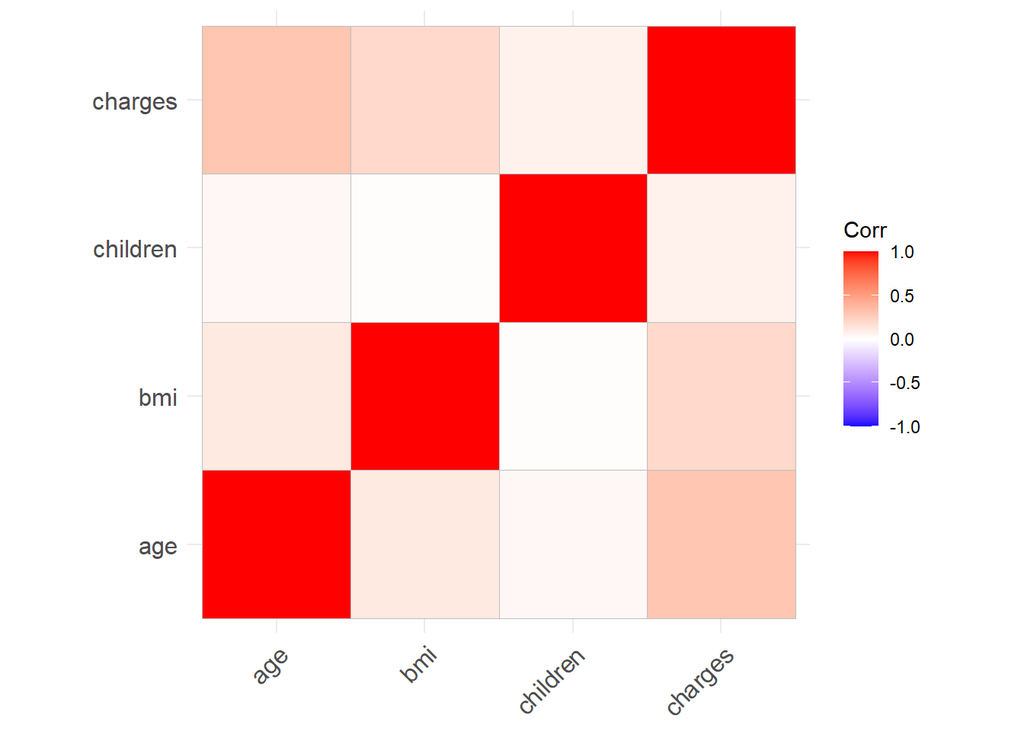

## Modello lineare semplice con charges

Charges è la variabile quantitativa che rappresenta le spese mediche, in questo punto costruiamo dei modelli di regressione lineare semplice tra charges e le altre variabili. Quello che ci aspettiamo prima di effettuare le regressioni è che le più efficaci siano l’età e il bmi, visto che sono le uniche variabili quantitative (con un discreto numero di realizzazioni) e quindi riescono ad identificare con maggior precisione le singole osservazioni nel dataset. Seguono ora output dei summary e grafici delle regressioni lineari semplici di charges con le altre variabili:

```
##
## Call:
## lm(formula = charges ~ age, data = insurance)
##
## Residuals:
##    Min     1Q Median     3Q    Max
##  -8059  -6671  -5939   5440  47829
##
## Coefficients:
##             Estimate Std. Error t value Pr(>|t|)
## (Intercept)   3165.9      937.1   3.378 0.000751 ***
## age            257.7       22.5  11.453  < 2e-16 ***
## ---
## Signif. codes:  0 '***' 0.001 '**' 0.01 '*' 0.05 '.' 0.1 ' ' 1
##
## Residual standard error: 11560 on 1336 degrees of freedom
## Multiple R-squared:  0.08941,    Adjusted R-squared:  0.08872
## F-statistic: 131.2 on 1 and 1336 DF,  p-value: < 2.2e-16
```

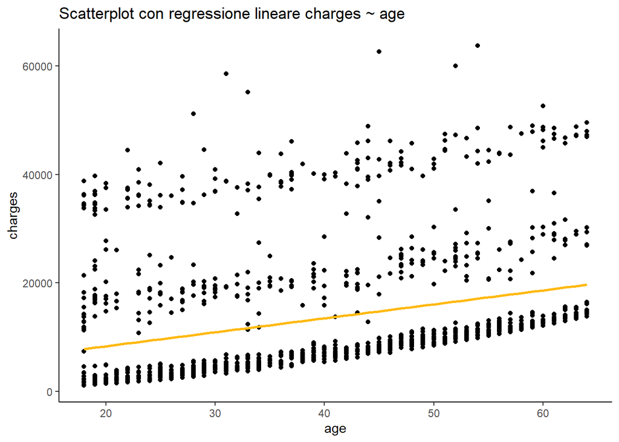

La retta di regressione non sembra avere un fit molto efficace con l’età: si osserva infatti come i dati siano distribuiti su tre “fasce”: una inferiore, con una densità di punti maggiore, grazie alla quale la retta di regressione è così vicina ai punti; una centrale ed una superiore, con numerosità visibilmente più basse, che sembrano essere più o meno parallele a quella inferiore. Ciò fa sì che il fit della retta non risulti particolarmente efficace. Per quanto rigurarda il summary, sembra dare ragione a quanto appena detto: l’$R^2$ si aggira intorno al 9%, la retta non riesce a spiegare efficacemente la varianza dei dati.

```
##
## Call:
## lm(formula = charges ~ bmi, data = insurance)
##
## Residuals:
##    Min     1Q Median     3Q    Max
## -20956  -8118  -3757   4722  49442
##
## Coefficients:
##             Estimate Std. Error t value Pr(>|t|)
## (Intercept)  1192.94    1664.80   0.717    0.474
## bmi           393.87      53.25   7.397 2.46e-13 ***
## ---
## Signif. codes:  0 '***' 0.001 '**' 0.01 '*' 0.05 '.' 0.1 ' ' 1
##
## Residual standard error: 11870 on 1336 degrees of freedom
## Multiple R-squared:  0.03934,    Adjusted R-squared:  0.03862
## F-statistic: 54.71 on 1 and 1336 DF,  p-value: 2.459e-13
```

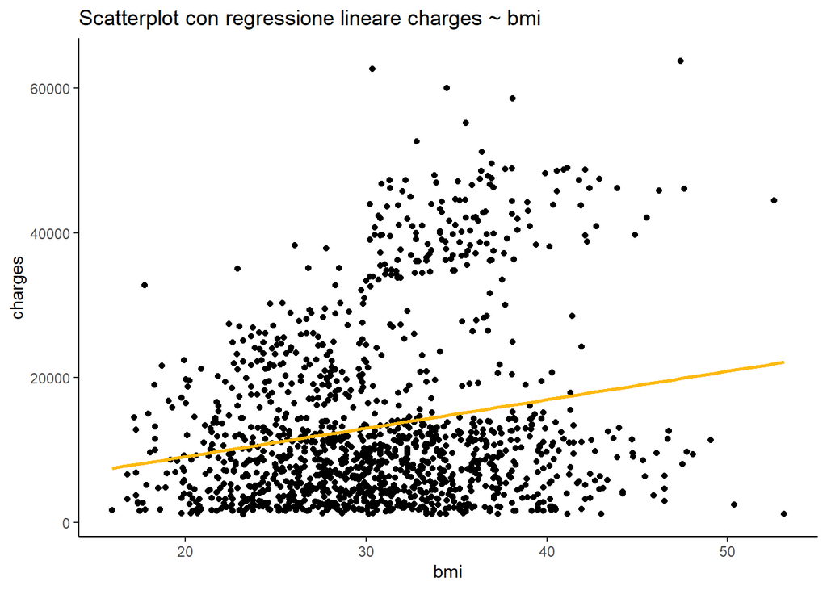

Il grafico tra le spese mediche e il BMI non sembra essere particolarmente efficace; la varianza dei dati non è ben descritta dalla retta (con un $R^2$ che si aggira intorno al 4%).

```
##
## Call:
## lm(formula = charges ~ children, data = insurance)
##
## Residuals:
##    Min     1Q Median     3Q    Max
## -11585  -8759  -4071   3468  51248
##
## Coefficients:
##             Estimate Std. Error t value Pr(>|t|)
## (Intercept)  12522.5      446.5  28.049   <2e-16 ***
## children       683.1      274.2   2.491   0.0129 *
## ---
## Signif. codes:  0 '***' 0.001 '**' 0.01 '*' 0.05 '.' 0.1 ' ' 1
##
## Residual standard error: 12090 on 1336 degrees of freedom
## Multiple R-squared:  0.004624,   Adjusted R-squared:  0.003879
## F-statistic: 6.206 on 1 and 1336 DF,  p-value: 0.01285
```

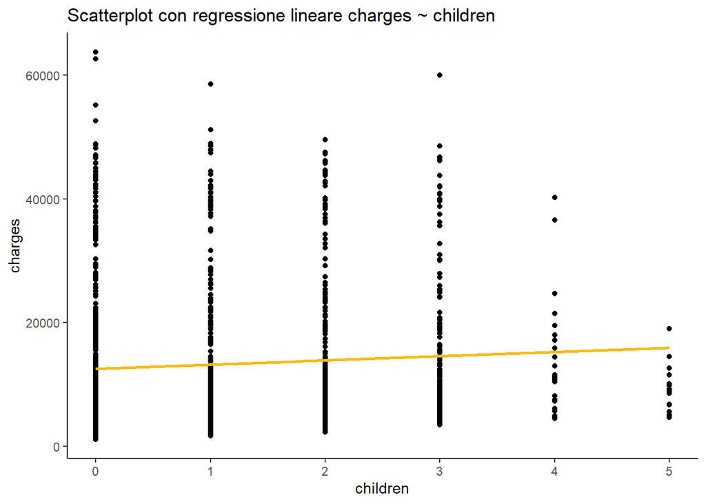

La variabile children è una variabile quantitativa di fatto, tuttavia con poche determinazioni. Come si osserva sia graficamente sia analiticamente, la retta è poco efficace, l’$R^2$ è minore dell’1%. In alternativa, si può costruire il modello con la variabile fattorizzata (osserviamo solo il summary e i boxplot delle distribuzioni):

```
##
## Call:
## lm(formula = charges ~ factor(children), data = insurance)
##
## Residuals:
##    Min     1Q Median     3Q    Max
## -12770  -8720  -3878   3476  51404
##
## Coefficients:
##                   Estimate Std. Error t value Pr(>|t|)
## (Intercept)        12366.0      503.3  24.570  < 2e-16 ***
## factor(children)1    365.2      837.9   0.436  0.66302
## factor(children)2   2707.6      926.9   2.921  0.00355 **
## factor(children)3   2989.3     1086.0   2.753  0.00599 **
## factor(children)4   1484.7     2463.6   0.603  0.54685
## factor(children)5  -3579.9     2886.4  -1.240  0.21509
## ---
## Signif. codes:  0 '***' 0.001 '**' 0.01 '*' 0.05 '.' 0.1 ' ' 1
##
## Residual standard error: 12060 on 1332 degrees of freedom
## Multiple R-squared:  0.01222,    Adjusted R-squared:  0.008517
## F-statistic: 3.297 on 5 and 1332 DF,  p-value: 0.005786
```

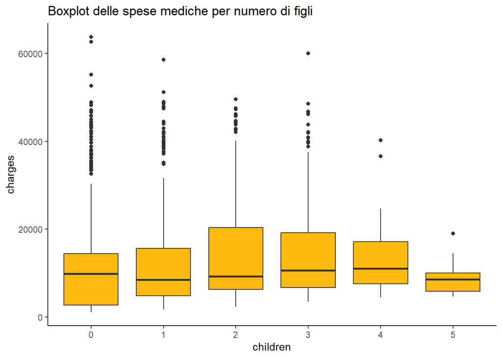

```
##
## Call:
## lm(formula = charges ~ smoker, data = insurance)
##
## Residuals:
##    Min     1Q Median     3Q    Max
## -19221  -5042   -919   3705  31720
##
## Coefficients:
##             Estimate Std. Error t value Pr(>|t|)
## (Intercept)   8434.3      229.0   36.83   <2e-16 ***
## smokeryes    23616.0      506.1   46.66   <2e-16 ***
## ---
## Signif. codes:  0 '***' 0.001 '**' 0.01 '*' 0.05 '.' 0.1 ' ' 1
##
## Residual standard error: 7470 on 1336 degrees of freedom
## Multiple R-squared:  0.6198, Adjusted R-squared:  0.6195
## F-statistic:  2178 on 1 and 1336 DF,  p-value: < 2.2e-16
```

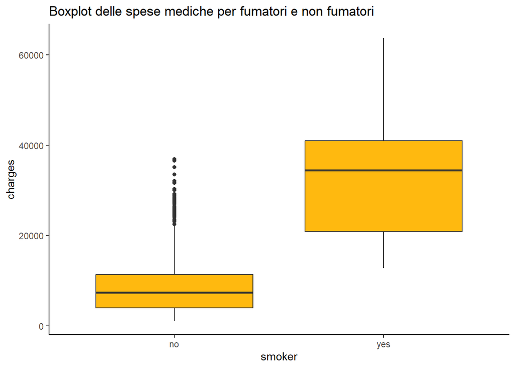

Per quanto riguarda la variabile smoker, una variabile dicotomica con solamente 2 realizzazioni, i risultati sono sorprendenti: la variabile spiega da sola oltre il 60% della varianza facendo riferimento all’$R^2$, e anche graficamente è evidente la differenza di distribuzione delle spese mediche tra fumatori e non fumatori.

```
##
## Call:
## lm(formula = charges ~ sex, data = insurance)
##
## Residuals:
##    Min     1Q Median     3Q    Max
## -12835  -8435  -3980   3476  51201
##
## Coefficients:
##             Estimate Std. Error t value Pr(>|t|)
## (Intercept)  12569.6      470.1  26.740   <2e-16 ***
## sexmale       1387.2      661.3   2.098   0.0361 *
## ---
## Signif. codes:  0 '***' 0.001 '**' 0.01 '*' 0.05 '.' 0.1 ' ' 1
##
## Residual standard error: 12090 on 1336 degrees of freedom
## Multiple R-squared:  0.003282,   Adjusted R-squared:  0.002536
## F-statistic:   4.4 on 1 and 1336 DF,  p-value: 0.03613
```

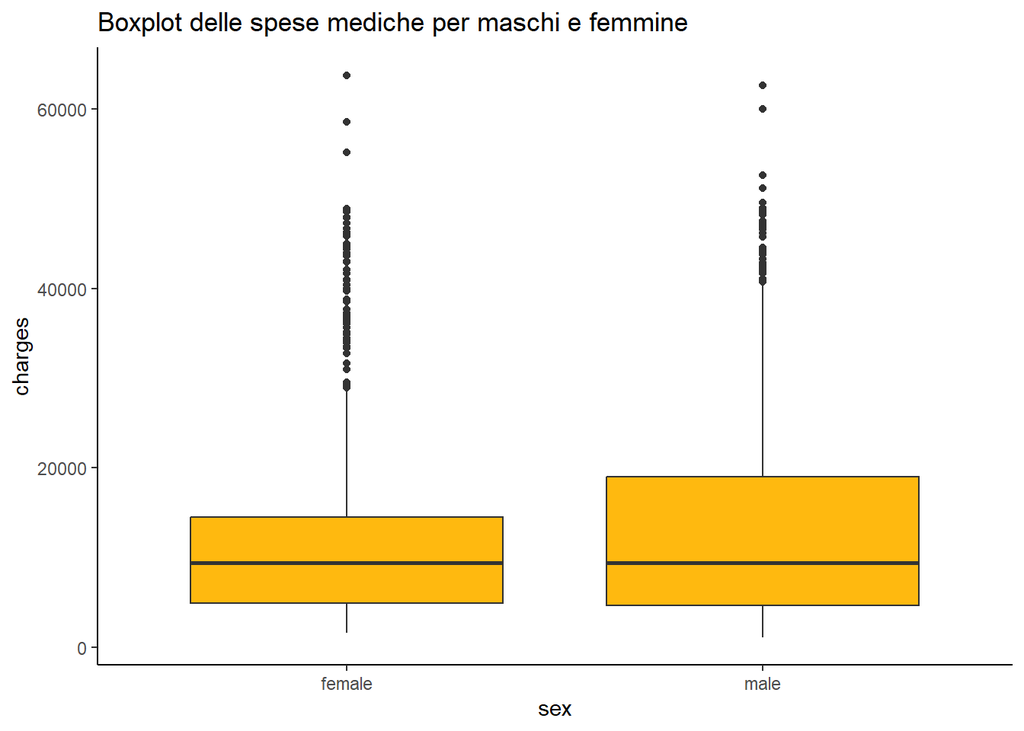

Il sesso non risulta essere una variabile particolarmente significativa, si evince dall’$R^2$ particolarmente basso e dalla significatività del coefficiente che, seppur accettiamo con un livello di confidenza del 95%, è molto più bassa rispetto ai coefficienti visti fin’ora. Inoltre, il valore del coefficiente è più piccolo dell’intercetta di un’ordine di grandezza, ciò significa che la differenza di spese mediche tra maschi e femmine descritta dal modello è molto piccola.  
Anche graficamente è facile notare questa evidenza, sebbene i maschi abbiano più dispersione intorno alla media.

```
##
## Call:
## lm(formula = charges ~ region, data = insurance)
##
## Residuals:
##    Min     1Q Median     3Q    Max
## -13614  -8463  -3793   3385  49035
##
## Coefficients:
##                 Estimate Std. Error t value Pr(>|t|)
## (Intercept)      13406.4      671.3  19.971   <2e-16 ***
## regionnorthwest   -988.8      948.6  -1.042    0.297
## regionsoutheast   1329.0      922.9   1.440    0.150
## regionsouthwest  -1059.4      948.6  -1.117    0.264
## ---
## Signif. codes:  0 '***' 0.001 '**' 0.01 '*' 0.05 '.' 0.1 ' ' 1
##
## Residual standard error: 12080 on 1334 degrees of freedom
## Multiple R-squared:  0.006634,   Adjusted R-squared:  0.0044
## F-statistic:  2.97 on 3 and 1334 DF,  p-value: 0.03089
```

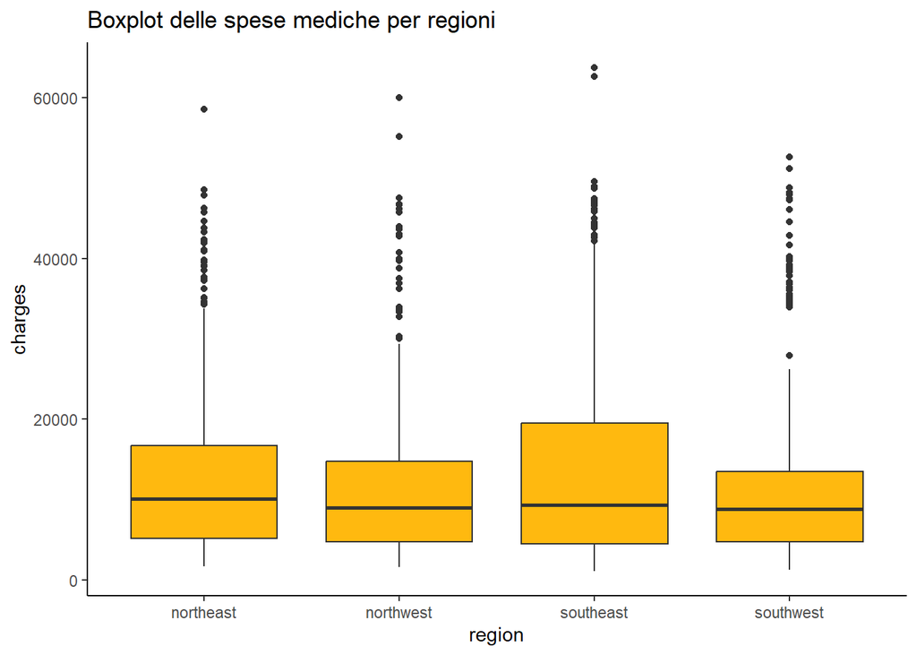

## Modello lineare charges ~ age

Il modello di regressione lineare assume la seguente forma:
$$charges = \beta_0 + \beta_1*age$$
Ristampiamo il summary:

```
##
## Call:
## lm(formula = charges ~ age, data = insurance)
##
## Residuals:
##    Min     1Q Median     3Q    Max
##  -8059  -6671  -5939   5440  47829
##
## Coefficients:
##             Estimate Std. Error t value Pr(>|t|)
## (Intercept)   3165.9      937.1   3.378 0.000751 ***
## age            257.7       22.5  11.453  < 2e-16 ***
## ---
## Signif. codes:  0 '***' 0.001 '**' 0.01 '*' 0.05 '.' 0.1 ' ' 1
##
## Residual standard error: 11560 on 1336 degrees of freedom
## Multiple R-squared:  0.08941,    Adjusted R-squared:  0.08872
## F-statistic: 131.2 on 1 and 1336 DF,  p-value: < 2.2e-16
```

Utilizzando i coefficienti proposti dalla funzione di R, si ottiene la formula:
$$charges = 3165.9 +
257.7*age$$
L’interpretazione dei coefficienti risulta piuttosto immediata: $\beta_o$ (3165.9) è la spesa medica stimata per una persona di 0 anni; questa non può considerarsi a tutti gli effetti un’interpretazione sensata poiché, sebbene le persone possano avere 0 anni, il nostro dataset contiene dati di persone che vanno dai 18 anni in su. $\beta_1$ (257.7), invece, è l’incremento delle spese mediche per un’aumento unitario dell’età; sostanzialmente, una persona di età $t$ paga 257.7 in meno di una persona di età $t+1$.

Si passa ora all’analisi dei residui; nei residui si cerca:  
- Normalità  
- Linearità  
- Omoschedasticità  
Cominciamo con la visualizzazione grafica:

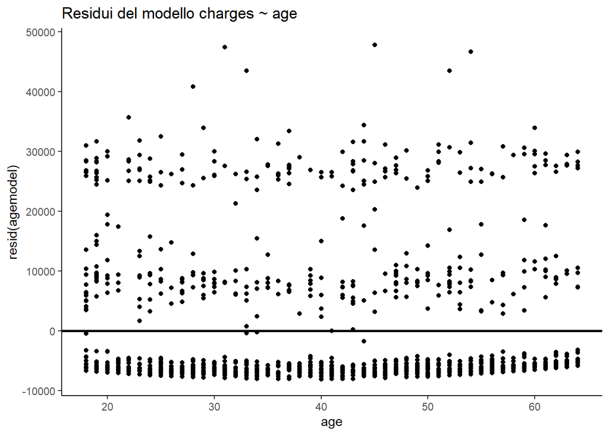

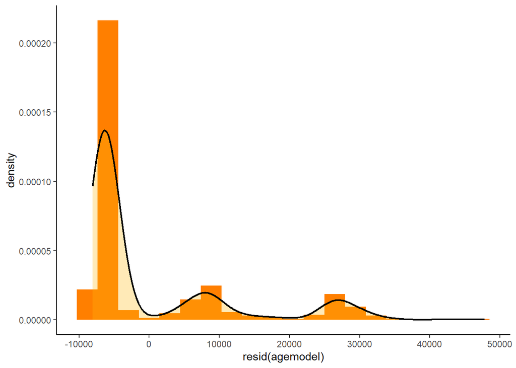

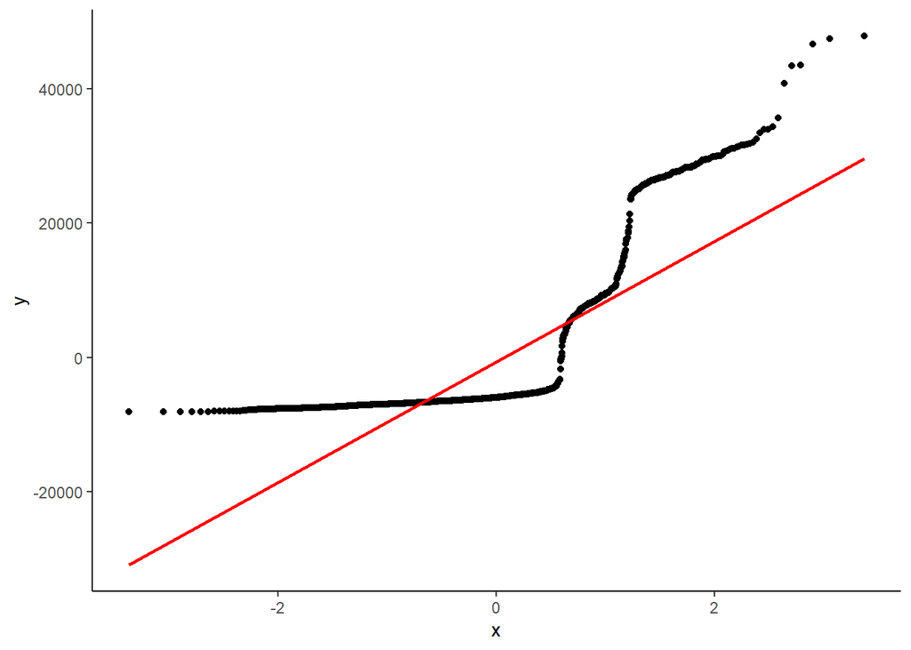

Risulta evidente l’inadeguatezza dei residui, il loro problema più evidente è la non normalità.  
Si possono provare delle trasformazioni delle variabili per migliorare questo problema (consapevolmente che l’interpretazione dei coefficienti diventerà più difficile). La trasformazione logaritmica della variabile charges sembra risolvere parte del problema di non normalità, tuttavia si generano dei residui maggiormente eteroschedastici.

```
##
## Call:
## lm(formula = log(charges) ~ age, data = insurance)
##
## Residuals:
##     Min      1Q  Median      3Q     Max
## -1.3433 -0.4166 -0.3094  0.5000  2.1999
##
## Coefficients:
##             Estimate Std. Error t value Pr(>|t|)
## (Intercept) 7.744247   0.063336  122.27   <2e-16 ***
## age         0.034545   0.001521   22.71   <2e-16 ***
## ---
## Signif. codes:  0 '***' 0.001 '**' 0.01 '*' 0.05 '.' 0.1 ' ' 1
##
## Residual standard error: 0.7813 on 1336 degrees of freedom
## Multiple R-squared:  0.2786, Adjusted R-squared:  0.2781
## F-statistic:   516 on 1 and 1336 DF,  p-value: < 2.2e-16
```

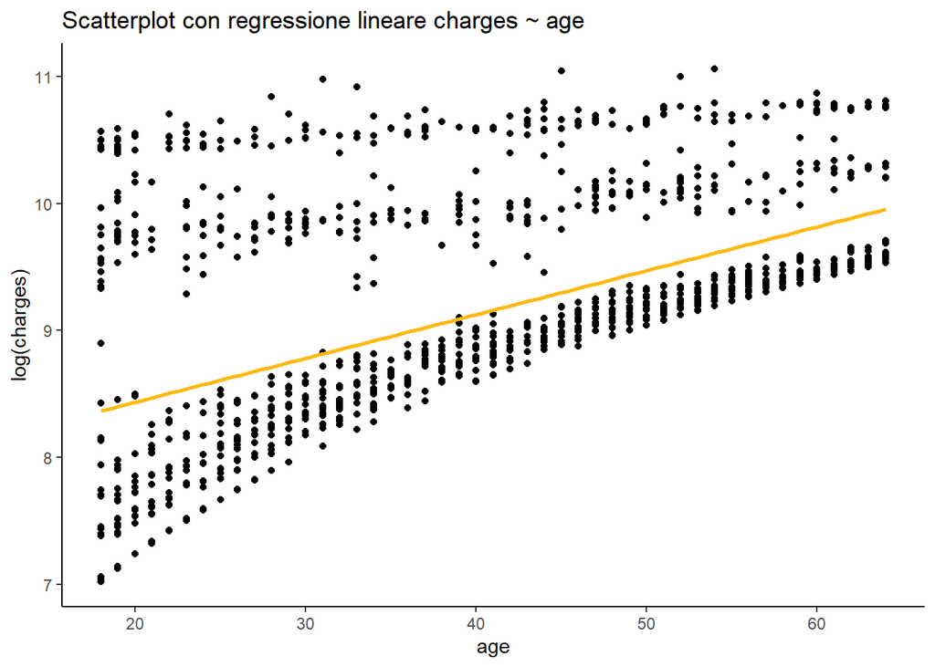

[figure not shown]

La radice e le trasformazioni della variabile età, invece, non sembrano risolvere il problema. Per semplicità interpretativa decidiamo di continuare a studiare il modello senza trasformazioni, preferendo l’omoschedasticità alla normalità dei residui.

## Rappresentazione grafica del modello

Si rappresenta il modello stampando lo scatterplot tra le variabili age e charges, aggiungendo la retta di regressione e due bande che rappresentano lo scostamento di un anno sull’età ed il rispettivo incremento atteso sulle spese mediche stimato dal modello (la rappresentazione semplice del modello è già stata fatta nei punti precedenti):

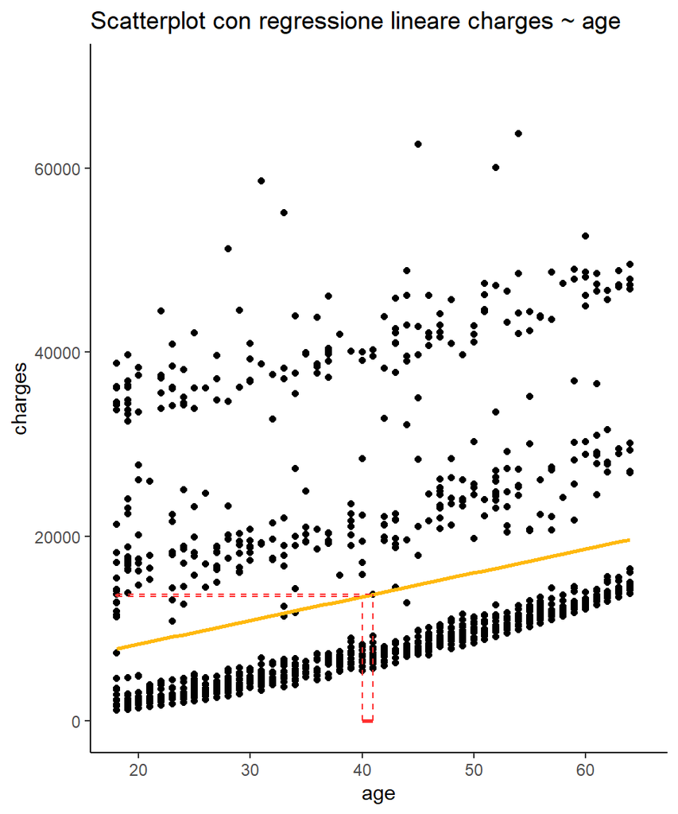

## Modello di charges e age con interazione con la variabile smoker

Si prova ora a introdurre l’interazione tra age e smoker nel modello proposto fin’ora. Osserviamo i summary dei tre modelli diversi che si ottengono:

```
##
## Call:
## lm(formula = charges ~ age + smoker, data = insurance)
##
## Residuals:
##      Min       1Q   Median       3Q      Max
## -16088.1  -2046.8  -1336.4   -212.7  28760.0
##
## Coefficients:
##             Estimate Std. Error t value Pr(>|t|)
## (Intercept) -2391.63     528.30  -4.527 6.52e-06 ***
## age           274.87      12.46  22.069  < 2e-16 ***
## smokeryes   23855.30     433.49  55.031  < 2e-16 ***
## ---
## Signif. codes:  0 '***' 0.001 '**' 0.01 '*' 0.05 '.' 0.1 ' ' 1
##
## Residual standard error: 6397 on 1335 degrees of freedom
## Multiple R-squared:  0.7214, Adjusted R-squared:  0.721
## F-statistic:  1728 on 2 and 1335 DF,  p-value: < 2.2e-16
```

```
##
## Call:
## lm(formula = charges ~ age + age:smoker, data = insurance)
##
## Residuals:
##    Min     1Q Median     3Q    Max
## -21245  -3381  -1690    667  33921
##
## Coefficients:
##               Estimate Std. Error t value Pr(>|t|)
## (Intercept)    2554.79     574.87   4.444 9.56e-06 ***
## age             162.64      13.95  11.662  < 2e-16 ***
## age:smokeryes   550.12      11.68  47.088  < 2e-16 ***
## ---
## Signif. codes:  0 '***' 0.001 '**' 0.01 '*' 0.05 '.' 0.1 ' ' 1
##
## Residual standard error: 7090 on 1335 degrees of freedom
## Multiple R-squared:  0.6578, Adjusted R-squared:  0.6573
## F-statistic:  1283 on 2 and 1335 DF,  p-value: < 2.2e-16
```

```
##
## Call:
## lm(formula = charges ~ age * smoker, data = insurance)
##
## Residuals:
##      Min       1Q   Median       3Q      Max
## -16072.5  -2043.0  -1348.7   -258.9  28814.6
##
## Coefficients:
##               Estimate Std. Error t value Pr(>|t|)
## (Intercept)   -2091.42     582.57  -3.590 0.000343 ***
## age             267.25      13.93  19.187  < 2e-16 ***
## smokeryes     22385.55    1278.73  17.506  < 2e-16 ***
## age:smokeryes    37.99      31.09   1.222 0.222037
## ---
## Signif. codes:  0 '***' 0.001 '**' 0.01 '*' 0.05 '.' 0.1 ' ' 1
##
## Residual standard error: 6396 on 1334 degrees of freedom
## Multiple R-squared:  0.7217, Adjusted R-squared:  0.7211
## F-statistic:  1153 on 3 and 1334 DF,  p-value: < 2.2e-16
```

Dai summary risulta immediatamente evidente una cosa: la variabile smoker apporta un miglioramento significativo rispetto al modello dotato solamente della variabile age; tuttavia, sia il modello additivo (con $R^2$ maggiore) sia quello con la sola interazione sembrano essere efficaci, mentre in quello in cui sono presenti entrambi la componente con l’interazione risulta non significativa.  
Ci aspettiamo quindi di scegliere o il modello additivo, o quello con l’interazione. Per decidere, confrontiamo gli AIC:

```
##        df      AIC
## model1  3 28835.95
## model2  4 27253.32
## model3  4 27528.52
## model4  5 27253.83
```

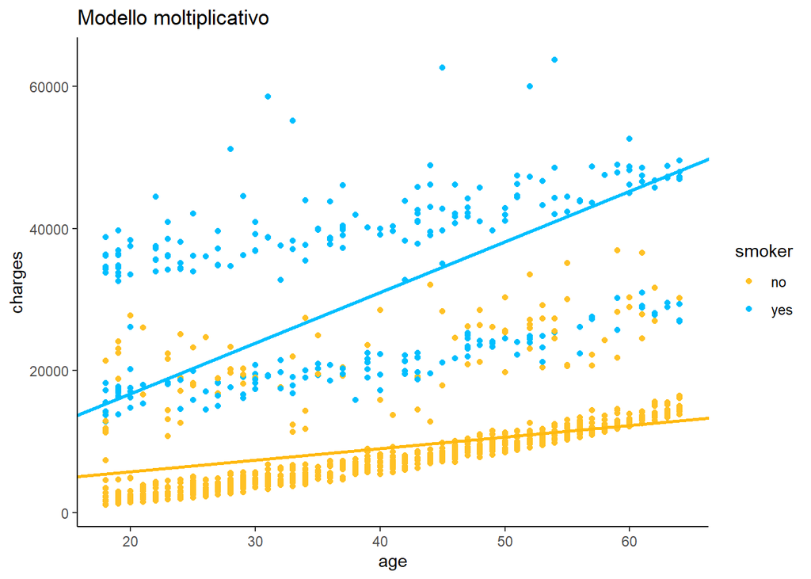

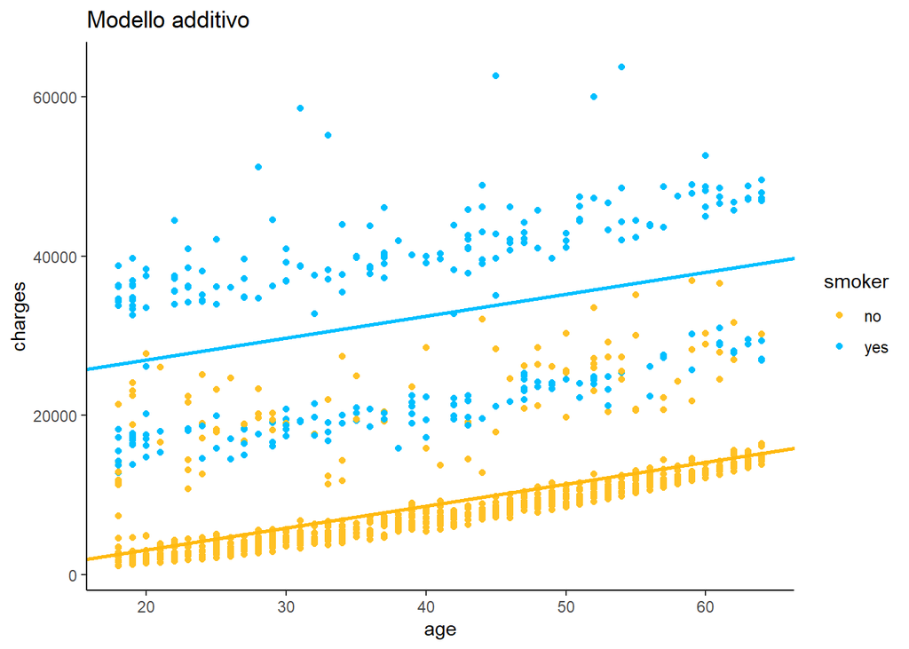

Graficamente il modello additivo sembra migliore, poiché in entrambi si percepisce l’influenza di una terza variabile, e nel modello moltiplicativo l’effetto sembra essere più bias.

## Analisi del modello con age e smoker

Dopo la visualizzazione grafica e del summary del modello (presenti nel punto precedente), visualizziamo i residui:

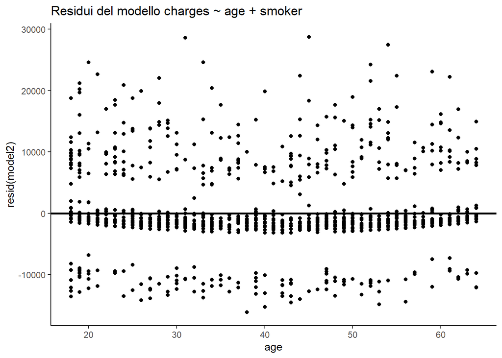

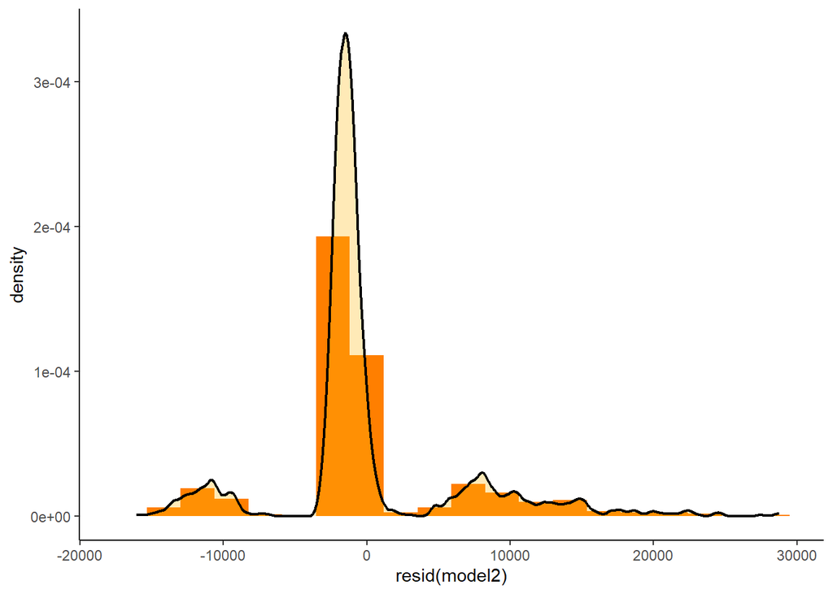

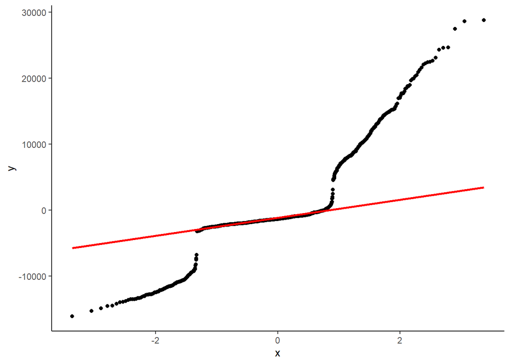

Il modello, anche dall’osservazione dei residui, sembra simile a quello precedente ottenuto con la sola variabile age ma migliorato: i residui sembrano abbastanza lineari e omoschedastici, ma la normalità è ancora lontana; anche in questo caso si potrebbe effettuare una trasformazione alla variabile charges, ma il logaritmo rende i residui eteroschedastici mentre la radice non ha un effetto molto evidente.

A questo punto si visualizza il grafico con le bande rappresentanti uno scostamento di un anno di età:

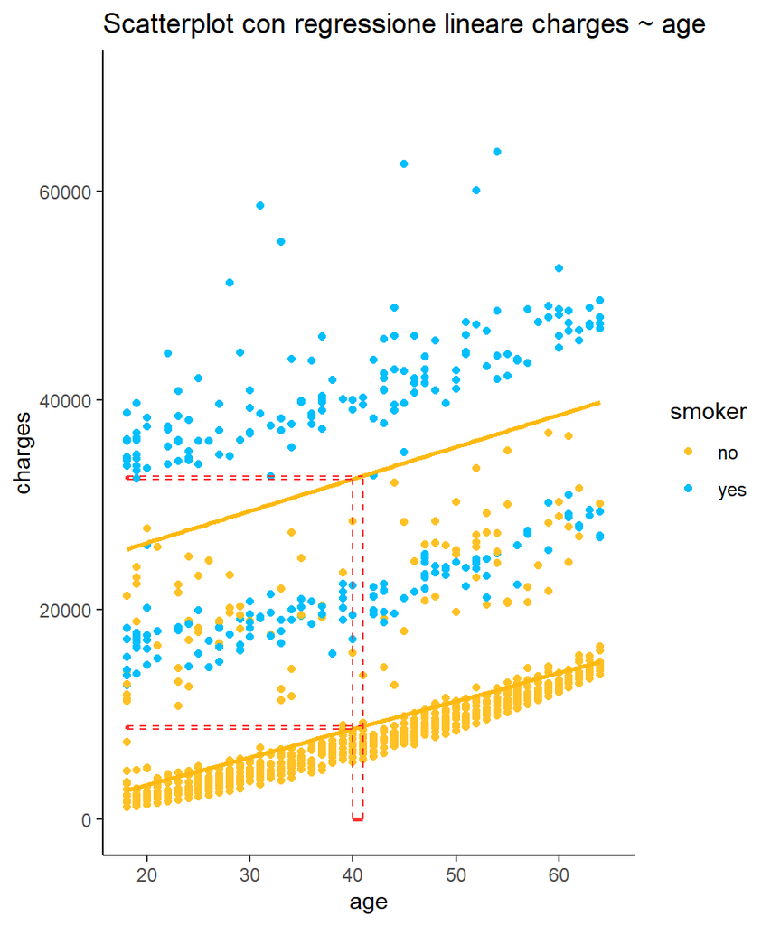

## Previsione delle spese mediche per un 40enne

Ora si effettuano le previsioni delle spese mediche supportate da un 40enne utilizzando il modello additivo tra age e smoker.  
Come prima cosa, valutiamo le spese mediche stimate di un 40enne non fumatore:

```
## [1] 8603.221
```

Adesso valutiamo le spese mediche stimate di un 40enne fumatore:

```
## [1] 32458.53
```

Le spese mediche per un fumatore 40enne sono mediamente quasi 4 volte tanto quelle di un coetaneo non fumatore.  
La morale di questi homework è non fumare.